# Experience vs. description based decision-making project: DDRL with Stan (probabilistic estimation)

# Set up

```r
helpers_path = here('analysis/helpers/')
```

Set theme for plots

```r
theme_set(theme_bw())
```

# Pure dd

- Not hierarchical
- Estimating individual threshold, bias, drift rate and NDT
- Not including value difference between options
- No learning

```r
source(paste0(helpers_path,'ddrlModels/fit_pure_dd_stan.R'))
par_ests_var = par_ests
```

## Log likelihood distributions

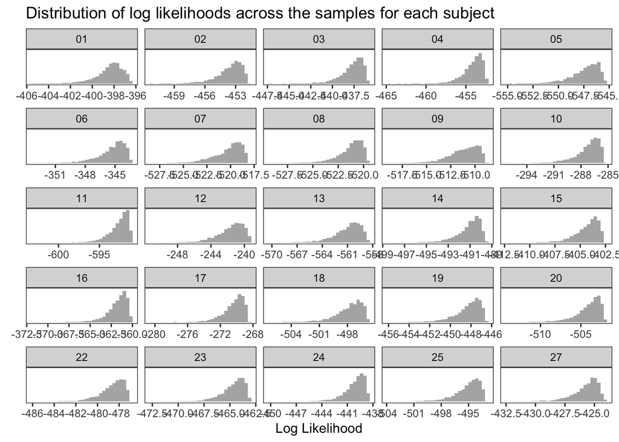

```r
par_ests_var %>%
  filter(par == "alpha") %>% #filtering one parameter bc likelihood for combinations of parameters is the same. nothing special abt alpha here
  ggplot(aes(logLik)) +
  geom_histogram(alpha=.5, bins=30, position="identity")+
  facet_wrap(~subnum, scales="free_x")+
  xlab("Log Likelihood")+
  ylab("")+
  ggtitle("Distribution of log likelihoods across the samples for each subject")+
  theme(axis.text.y=element_blank(),
        axis.ticks.y=element_blank(),
        panel.grid = element_blank())
```

## Parameter estimates

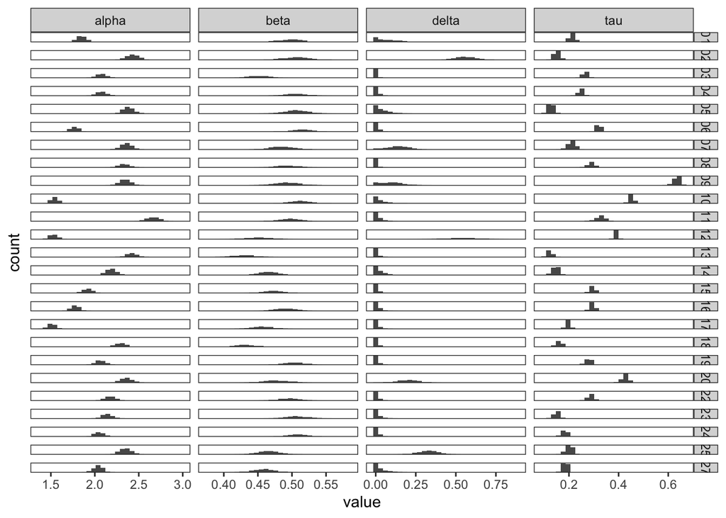

```r
par_ests_var %>%
  ggplot(aes(value)) +
  geom_histogram(bins=30)+
  facet_grid(subnum ~ par, scales="free")+
  theme(axis.text.y=element_blank(),
        axis.ticks.y=element_blank(),
        panel.grid = element_blank())
```

## Covariance between parameters

```r
tmp = par_ests_var %>%
  group_by(par) %>%
  mutate(iter = 1:n()) %>%
  group_by(iter) %>%
  spread(par, value) %>%
  ungroup() %>%
  select(-iter, -logLik, -subnum)

round(cor(tmp), 3)
```

```
##        alpha   beta  delta    tau
## alpha  1.000 -0.019  0.030 -0.182
## beta  -0.019  1.000 -0.118  0.173
## delta  0.030 -0.118  1.000  0.078
## tau   -0.182  0.173  0.078  1.000
```

## Posterior predictive checks

Using mean posterior estimates

Predicted vs actual RT distributions conditioned on choice

```r
sub_par_ests_var = par_ests_var %>%
  group_by(subnum , par) %>%
  summarise(mean_val = mean(value), .groups="keep") %>%
  spread(par, mean_val)
```

```r
sim_data_var = data.frame()
for(i in 1:nrow(sub_par_ests_var)){

  sim_sub_data = rwiener(n = 300, alpha = sub_par_ests_var$alpha[i], tau = sub_par_ests_var$tau[i], beta = sub_par_ests_var$beta[i], delta = sub_par_ests_var$delta[i])
  sim_sub_data$subnum = sub_par_ests_var$subnum[i]
  if(i == 1){
    sim_data_var = sim_sub_data
  } else{
    sim_data_var = rbind(sim_data_var, sim_sub_data)
  }
}
```

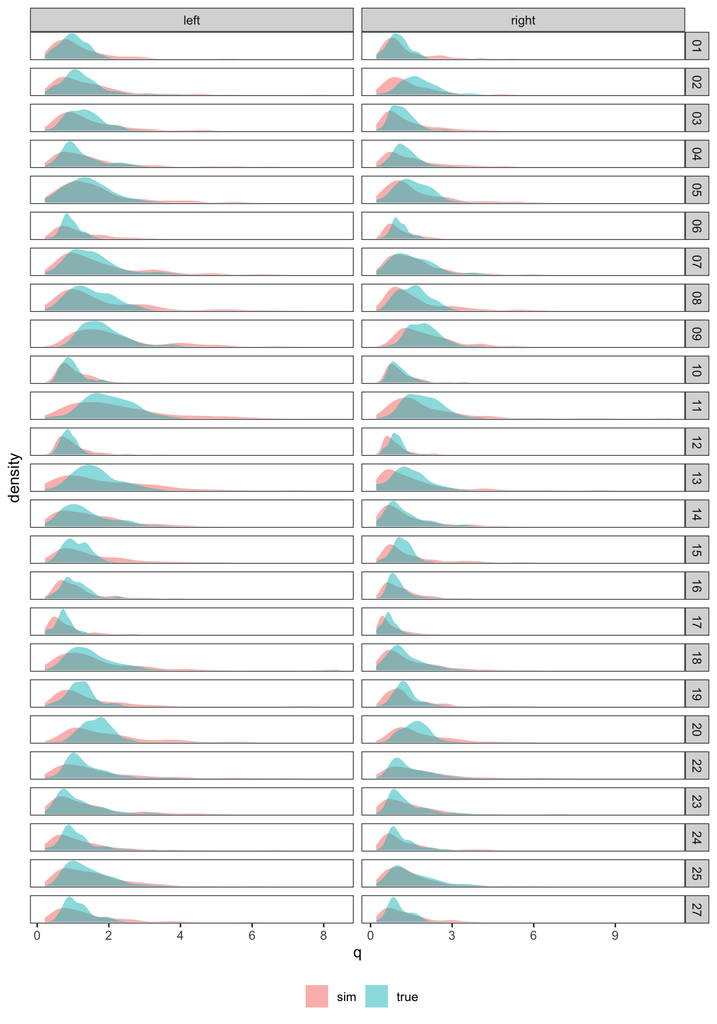

```r
sim_data_var %>%
  mutate(resp = ifelse(resp == "upper", "left", "right"),
         data_type = "sim") %>%
  rbind(clean_beh_data %>%
          select(subnum, choiceLeft,reactionTime) %>%
          rename(q=reactionTime, resp=choiceLeft) %>%
          mutate(resp = ifelse(resp == 1, "left", "right"),
                 data_type = "true")) %>%
  ggplot(aes(q, fill=data_type))+
  geom_density(alpha=.5, color=NA)+
  facet_grid(subnum~resp, scales="free")+
  theme(axis.text.y=element_blank(),
        axis.ticks.y=element_blank(),
        panel.grid = element_blank(),
        legend.position = "bottom",
        legend.title = element_blank())
```

# Pure dd with fixed pars

- Boundary separation alpha fixed at 2
- Bias beta fixed at .5 (no bias)
- NDT tau fixed at .1

```r
source(paste0(helpers_path,'ddrlModels/fit_pure_dd_fixpars_stan.R'))
par_ests_fix = par_ests
```

## Log likelihood distributions

Compare log likelihoods to previous model where three other parameters were estimated instead of fixed.

Model with fixed parameters is consistently a worse fit.

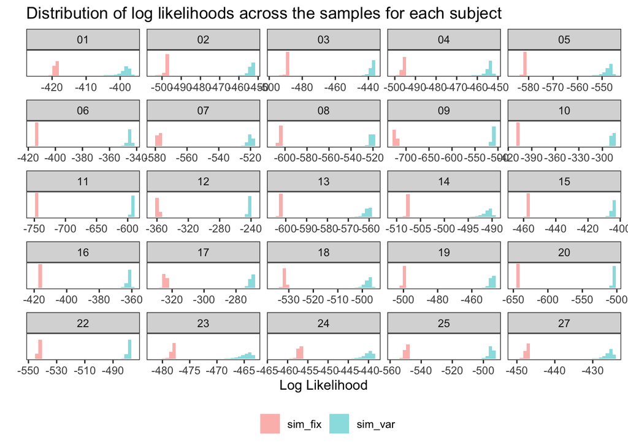

```r
par_ests_fix %>%
  filter(par == "delta") %>% #filtering one parameter bc likelihood for combinations of parameters is the same. nothing special abt alpha here
  mutate(data_type="sim_fix") %>%
  rbind(par_ests_var %>%
          filter(par == "delta") %>% #filtering one parameter bc likelihood for combinations of parameters is the same. nothing special abt alpha here
          mutate(data_type="sim_var")) %>%
  ggplot(aes(logLik, fill=data_type)) +
  geom_histogram(alpha=.5, bins=30, position="identity")+
  facet_wrap(~subnum, scales="free_x")+
  xlab("Log Likelihood")+
  ylab("")+
  ggtitle("Distribution of log likelihoods across the samples for each subject")+
  theme(axis.text.y=element_blank(),
        axis.ticks.y=element_blank(),
        panel.grid = element_blank(),
        legend.position = "bottom",
        legend.title = element_blank())
```

## Parameter estimates

Compare drift rates to previous model where three other parameters were estimated instead of fixed.

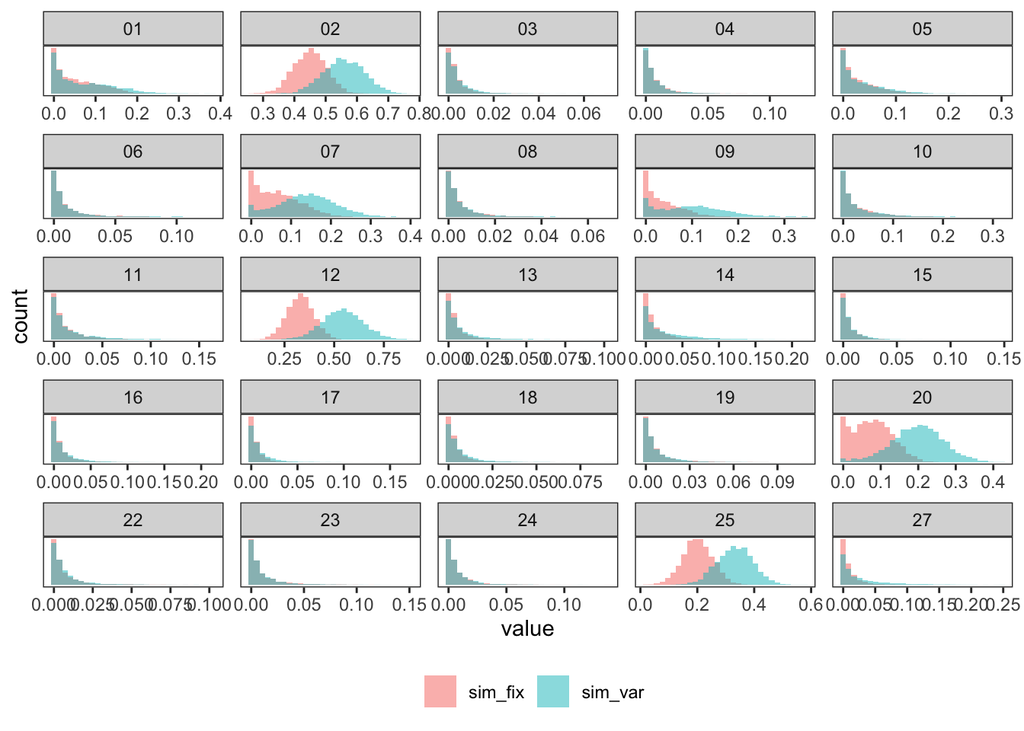

```r
par_ests_fix %>%
  mutate(data_type="sim_fix") %>%
  rbind(par_ests_var %>%
          filter(par == "delta") %>%
          mutate(data_type = "sim_var")) %>%
  ggplot(aes(value, fill=data_type)) +
  geom_histogram(bins=30, position="identity", alpha=.5)+
  facet_wrap(~subnum, scales="free")+
  theme(axis.text.y=element_blank(),
        axis.ticks.y=element_blank(),
        panel.grid = element_blank(),
        legend.position = "bottom",
        legend.title = element_blank())
```

## Posterior predictive checks

Using mean posterior estimates

Predicted vs actual RT distributions conditioned on choice

```r
sub_par_ests_fix= par_ests_fix %>%
  group_by(subnum , par) %>%
  summarise(mean_val = mean(value), .groups="keep") %>%
  spread(par, mean_val)
```

```r
sim_data_fix = data.frame()
for(i in 1:nrow(sub_par_ests_fix)){

  sim_sub_data = rwiener(n = 300, alpha = 2, tau = .1, beta = .5, delta = sub_par_ests_fix$delta[i])
  sim_sub_data$subnum = sub_par_ests_fix$subnum[i]
  if(i == 1){
    sim_data_fix = sim_sub_data
  } else{
    sim_data_fix = rbind(sim_data_fix, sim_sub_data)
  }
}
```

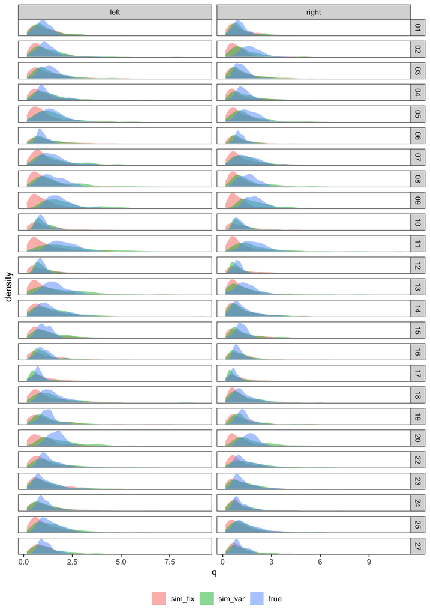

```r
sim_data_var %>%
  mutate(resp = ifelse(resp == "upper", "left", "right"),
         data_type = "sim_var") %>%
  rbind(sim_data_fix %>%
  mutate(resp = ifelse(resp == "upper", "left", "right"),
         data_type = "sim_fix")) %>%
  rbind(clean_beh_data %>%
          select(subnum, choiceLeft,reactionTime) %>%
          rename(q=reactionTime, resp=choiceLeft) %>%
          mutate(resp = ifelse(resp == 1, "left", "right"),
                 data_type = "true")) %>%
  ggplot(aes(q, fill=data_type))+
  geom_density(alpha=.5, color=NA)+
  facet_grid(subnum~resp, scales="free")+
  theme(axis.text.y=element_blank(),
        axis.ticks.y=element_blank(),
        panel.grid = element_blank(),
        legend.position = "bottom",
        legend.title = element_blank())
```

# Model 1c: DDRL

- Boundary separation alpha fixed at 2
- Bias beta fixed at .5 (no bias)
- NDT tau fixed at .1

```r
source(paste0(helpers_path,'ddrlModels/fit_ddrl_model1c.R'))
g_par_ests_ddrl = g_par_ests
par_ests_ddrl = par_ests
```

## Parameter estimates

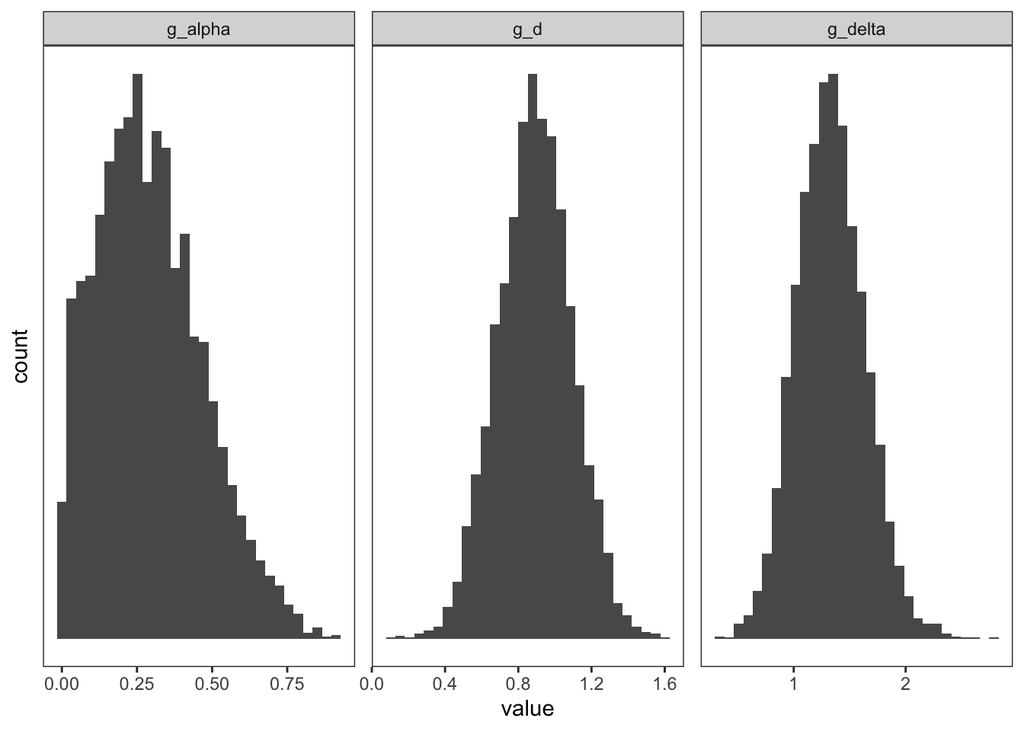

```r
g_par_ests_ddrl %>%
  ggplot(aes(value)) +
  geom_histogram(bins=30)+
  facet_wrap(~key, scales="free")+
  theme(axis.text.y=element_blank(),
        axis.ticks.y=element_blank(),
        panel.grid = element_blank())
```

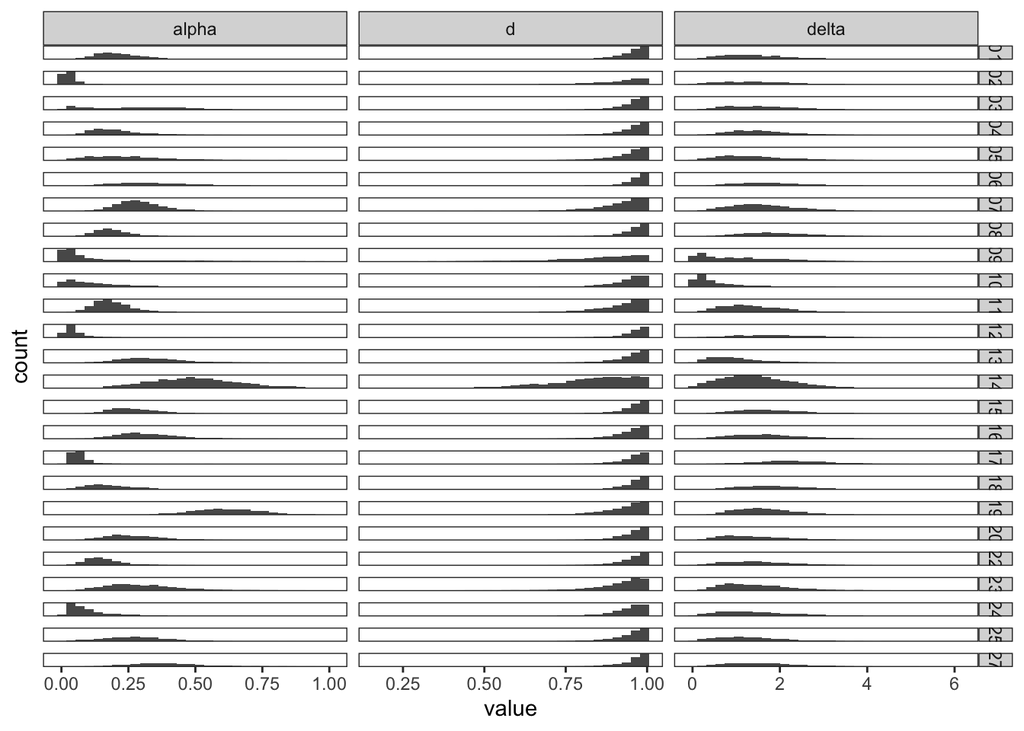

```r
par_ests_ddrl %>%
  ggplot(aes(value)) +
  geom_histogram(bins=30)+
  facet_grid(subnum ~ par, scales="free")+
  theme(axis.text.y=element_blank(),
        axis.ticks.y=element_blank(),
        panel.grid = element_blank())
```

How do the learning rate alphas and probability distortion deltas from this model compare to the hierarchical rl with softmax as the choice rule?

```r
source(paste0(helpers_path,'rlModels/fit_rl_hierarchical.R'))
```

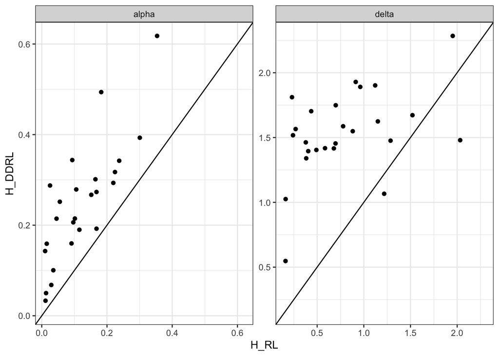

```r
par_ests %>%
  group_by(subnum , par) %>%
  summarise(mean_val = mean(value), .groups="keep") %>%
  spread(par, mean_val) %>%
  mutate(model = "H_RL") %>%
  rbind(par_ests_ddrl %>%
          group_by(subnum , par) %>%
          summarise(mean_val = mean(value), .groups="keep") %>%
          spread(par, mean_val) %>%
          mutate(model="H_DDRL")) %>%
  select(subnum, alpha, delta, model) %>%
  gather(key, value, -model, -subnum) %>%
  spread(model, value) %>%
  ggplot(aes(H_RL, H_DDRL))+
  geom_point()+
  geom_abline(aes(slope=1, intercept = 0))+
  facet_wrap_equal(~key, scales="free")
```

## Posterior predictive checks

```r
sub_par_ests_ddrl = par_ests_ddrl %>%
  group_by(subnum , par) %>%
  summarise(mean_val = mean(value), .groups="keep") %>%
  spread(par, mean_val)
```

Add inferred pars necessary for to simulate posterior predictive data

```r
# Add mean posterior estimates to clean_beh_data
clean_beh_data = sub_par_ests_ddrl %>%
  left_join(clean_beh_data, by='subnum')

source(paste0(helpers_path, 'get_qvals.R'))
## Add Q values of fractals to each trial
clean_beh_data = clean_beh_data %>%
  group_by(subnum) %>%
  do(get_qvals(., model_name="original")) %>%
  ungroup()

clean_beh_data = clean_beh_data %>%
  mutate(wpFrac = (delta*probFractalDraw)/(delta*probFractalDraw + (1-probFractalDraw)),
         leftLotteryEV = lotteryValue*lotteryProb,
         rightLotteryEV = referenceValue*referenceProb,
         valLeftBundle = (1-probFractalDraw)*leftLotteryEV + wpFrac*leftQValue,
         valRightBundle = (1-probFractalDraw)*rightLotteryEV + wpFrac*rightQValue,
         trial_drift = d * (valLeftBundle - valRightBundle))
```

```r
sim_data = data.frame()
for(i in 1:nrow(clean_beh_data)){

  # This will have to be for each trial bc the delta depends on the val difference in that trial
  # First generated the Q Values for all trials using the mean a posterior alpha for each subject

  sim_trial = rwiener(n =1, alpha = 2, tau = .1, beta = .5, delta = clean_beh_data$trial_drift[i])

  sim_trial$subnum = clean_beh_data$subnum[i]

  if(i == 1){
    sim_data = sim_trial
  } else{
    sim_data = rbind(sim_data, sim_trial)
  }
}
```

Compare both RTs

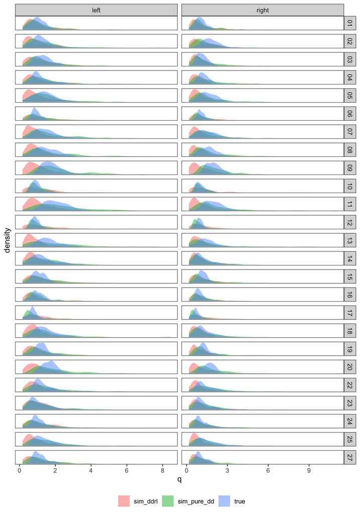

```r
sim_data %>%
  mutate(resp = ifelse(resp == "upper", "left", "right"),
         data_type = "sim_ddrl") %>%
  rbind(sim_data_var %>%
  mutate(resp = ifelse(resp == "upper", "left", "right"),
         data_type = "sim_pure_dd")) %>%
  rbind(clean_beh_data %>%
          select(subnum, choiceLeft,reactionTime) %>%
          rename(q=reactionTime, resp=choiceLeft) %>%
          mutate(resp = ifelse(resp == 1, "left", "right"),
                 data_type = "true")) %>%
  ggplot(aes(q, fill=data_type))+
  geom_density(alpha=.5, color=NA)+
  facet_grid(subnum~resp, scales="free")+
  theme(axis.text.y=element_blank(),
        axis.ticks.y=element_blank(),
        panel.grid = element_blank(),
        legend.position = "bottom",
        legend.title = element_blank())
```

Compare choice: Proportion of correctly predicted choice for each subject (color) and attribute relevance.

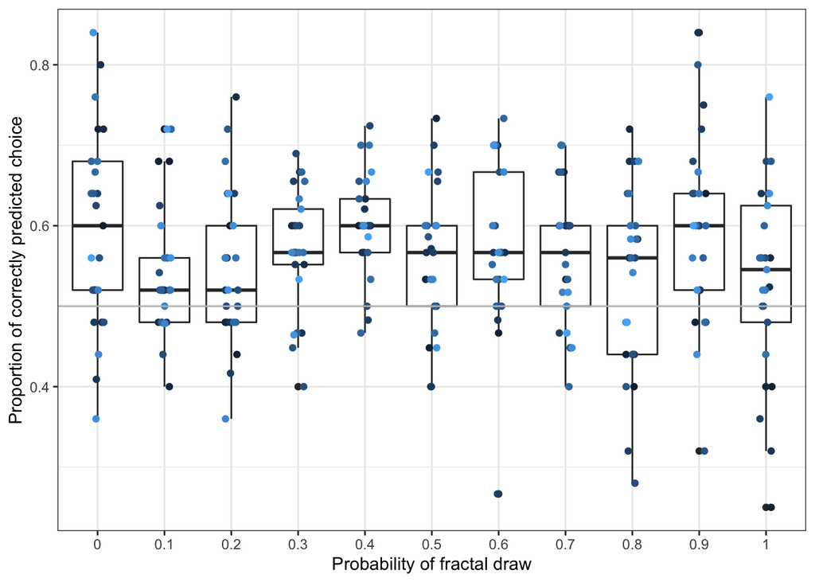

```r
sim_data %>%
  group_by(subnum) %>%
  mutate(trialNum = 1:n()) %>%
  left_join(clean_beh_data %>%
              select(subnum, choiceLeft, probFractalDraw) %>%
              group_by(subnum) %>%
              mutate(trialNum = 1:n()), by=c("subnum", "trialNum")) %>%
  mutate(predCorrect = ifelse(resp == "upper" & choiceLeft == 1, 1, ifelse(resp == "lower" & choiceLeft ==0, 1, 0))) %>%
  group_by(subnum, probFractalDraw) %>%
  summarise(.groups="keep",
            predCorrectProp = sum(predCorrect)/n()) %>%
  mutate(probFractalDraw = as.factor(probFractalDraw)) %>%
  ggplot(aes(probFractalDraw, predCorrectProp))+
  geom_boxplot()+
  geom_jitter(height=0, width=.1, aes(color=as.numeric(subnum)))+
  geom_hline(yintercept=.5, color="gray")+
  theme(legend.position = "none")+
  labs(y="Proportion of correctly predicted choice",
       x="Probability of fractal draw")
```

Improvements for this model: - Figure out how to incorporate sigma for the drift process - Constrain delta to be < 1?

Recovery of this model?

RPE and RDV signals generated by a true vs false parameter combination